# BOO 2025 - Example Analysis

Script 4: PCA - Answers

Pien van Zon

2025-05-18

> In this script, you will perform principal component analysis (PCA) to further explore patterns in the project data.

# 1 Setup

## 1.1 Clean

As before, we perform several setup steps at the start of the script to ensure our work is reproducible and clear.

**Exercise 1: Download the R markdown template, clean your environment, and set the following variables:**

- `root_dir` - project folder
- `cpm_path` - location of the `cpmData` object
- `metadata_path` - location of the `metaData` object

```r
rm(list=ls())

root_dir <- "C:/Users/pienz/Universiteit Leiden/BOO 2025 - BOO CDS Giulia team - BOO CDS Giulia team/Students/Pien/project/pienvanzon_BOO//"

cpm_path <- file.path(root_dir, "output", "cpmData_03_sampleQC.RData")

count_path <- file.path(root_dir, "output/countData_03_sampleQC.RData")
metadata_path <- file.path(root_dir, "output", "metaData_03_sampleQC.RData")
```

## 1.2 Packages

Two new packages are introduced in this script:

- `ComplexHeatmap` allows the drawing and annotation of heatmaps in R
- `circlize` allows for the drawing of circular plots, but is also used by `ComplexHeatmap` for colour functions like `colorRamp2()`

**Exercise 2: Load these packages alongside `tidyverse` into your R environment:**

```r
library(tidyverse)
library(ComplexHeatmap)
library(circlize)
```

## 1.3 Load data

**Exercise 3: Load the CPM and metadata into your R environment:**

```r
load(cpm_path)
load(count_path)
load(metadata_path)
```

# 2 PCA

## 2.1 Calculate

In high dimensional data (such as this data with around 10,000 genes), principal components (PCs) can be calculated and used to explore patterns. PCs can be thought of as a new axis in the data that captures the most variance possible in the fewest variables.

**Exercise 4: Use the `prcomp()` function to calculate PCs of the `cpmData`:**

```r
# Calculate PCs that capture the variance within CPM data
pcs <- prcomp(t(cpmData))
```

Apply PCA to our gene expression data so we can explore overall patterns, reduce dimensionality, and identify clusters or outliers in a dataset with thousands of genes.

Tolerance (or `tol`) can be adjusted to create more or fewer PCs, where a lower tolerance generates a higher number. If this argument is not set, the PCs calculated will capture the full variability of the CPM data.

## 2.2 Variance explained

**Exercise 5: Use the output of `prcomp()` to explore your PCs and calculate the variance in CPM values that they explain:**

**Hint**

Variance explained is the SD squared divided by the sum of the variance for all PCs.

```r
# Summarize PCs
summary(pcs)
```

```
## Importance of components:
##                             PC1       PC2       PC3       PC4      PC5
## Standard deviation     2252.450 1571.5132 1308.7296 1183.8716 897.5287
## Proportion of Variance    0.364    0.1772    0.1229    0.1006   0.0578
## Cumulative Proportion     0.364    0.5412    0.6641    0.7647   0.8225
##                              PC6       PC7       PC8       PC9      PC10
## Standard deviation     690.58767 520.53831 438.38926 406.52731 329.58677
## Proportion of Variance   0.03422   0.01944   0.01379   0.01186   0.00779
## Cumulative Proportion    0.85667   0.87611   0.88990   0.90176   0.90955
##                             PC11      PC12      PC13      PC14      PC15
## Standard deviation     320.27393 285.96968 268.27042 256.80402 239.49169
## Proportion of Variance   0.00736   0.00587   0.00516   0.00473   0.00412
## Cumulative Proportion    0.91691   0.92278   0.92794   0.93268   0.93679
##                             PC16      PC17     PC18      PC19      PC20
## Standard deviation     235.01776 217.85855 211.0854 202.42066 184.53519
## Proportion of Variance   0.00396   0.00341   0.0032   0.00294   0.00244
## Cumulative Proportion    0.94075   0.94416   0.9474   0.95030   0.95274
##                            PC21      PC22      PC23      PC24      PC25
## Standard deviation     183.0149 175.99007 174.67163 161.63068 155.35342
## Proportion of Variance   0.0024   0.00222   0.00219   0.00187   0.00173
## Cumulative Proportion    0.9551   0.95737   0.95955   0.96143   0.96316
##                             PC26      PC27      PC28     PC29      PC30
## Standard deviation     153.15621 151.43375 146.88476 144.4181 140.92910
## Proportion of Variance   0.00168   0.00165   0.00155   0.0015   0.00142
## Cumulative Proportion    0.96484   0.96649   0.96804   0.9695   0.97096
##                             PC31      PC32      PC33      PC34      PC35
## Standard deviation     138.35508 136.71862 133.73647 132.13010 130.08908
## Proportion of Variance   0.00137   0.00134   0.00128   0.00125   0.00121
## Cumulative Proportion    0.97233   0.97367   0.97496   0.97621   0.97742
##                             PC36      PC37      PC38      PC39      PC40
## Standard deviation     128.57773 127.47185 126.28067 124.75484 122.67075
## Proportion of Variance   0.00119   0.00117   0.00114   0.00112   0.00108
## Cumulative Proportion    0.97861   0.97977   0.98092   0.98204   0.98312
##                             PC41      PC42      PC43     PC44      PC45
## Standard deviation     121.94749 120.63856 119.43728 117.9579 117.24579
## Proportion of Variance   0.00107   0.00104   0.00102   0.0010   0.00099
## Cumulative Proportion    0.98418   0.98523   0.98625   0.9872   0.98823
##                             PC46      PC47      PC48      PC49      PC50
## Standard deviation     115.86628 115.05514 113.16663 112.91669 111.15005
## Proportion of Variance   0.00096   0.00095   0.00092   0.00091   0.00089
## Cumulative Proportion    0.98920   0.99015   0.99107   0.99198   0.99287
##                             PC51      PC52      PC53      PC54      PC55
## Standard deviation     110.83069 109.00493 108.44257 107.10188 106.52321
## Proportion of Variance   0.00088   0.00085   0.00084   0.00082   0.00081
## Cumulative Proportion    0.99375   0.99460   0.99544   0.99627   0.99708
##                            PC56      PC57      PC58     PC59      PC60
## Standard deviation     105.4220 104.25722 101.13834 91.95579 1.771e-12
## Proportion of Variance   0.0008   0.00078   0.00073  0.00061 0.000e+00
## Cumulative Proportion    0.9979   0.99866   0.99939  1.00000 1.000e+00
```

```r
# Calculate variance explained
var_explained =
  data.frame(PC = 1:nrow(metaData),
             var_explained = round(pcs$sdev^2 / sum(pcs$sdev^2), 3))

# Inspect
var_explained
```

| PC | var_explained |
| --- | --- |
| 1 | 0.364 |
| 2 | 0.177 |
| 3 | 0.123 |
| 4 | 0.101 |
| 5 | 0.058 |
| 6 | 0.034 |
| 7 | 0.019 |
| 8 | 0.014 |
| 9 | 0.012 |
| 10 | 0.008 |

[output cut: 50 more lines]

Here, we see that 60 PCs have been calculated and combined they capture the full variability of our CPM data (shown by the cumulative proportion).

Principal Component Analysis (PCA) revealed that the first principal component (PC1) captures 36.4% of the total variance in the CPM data, while the first four PCs together explain over 76%. This indicates that most of the variation in gene expression can be summarized in just a few dimensions, supporting the use of PCA for downstream visualization and exploratory analysis.

## 2.3 Screeplot

A screeplot can be used to visualize how each subsequent PC captures less and less of the total variance in the data.

**Exercise 6: Plot the top 20 calculated PCs against the variance they explain to generate a screeplot:**

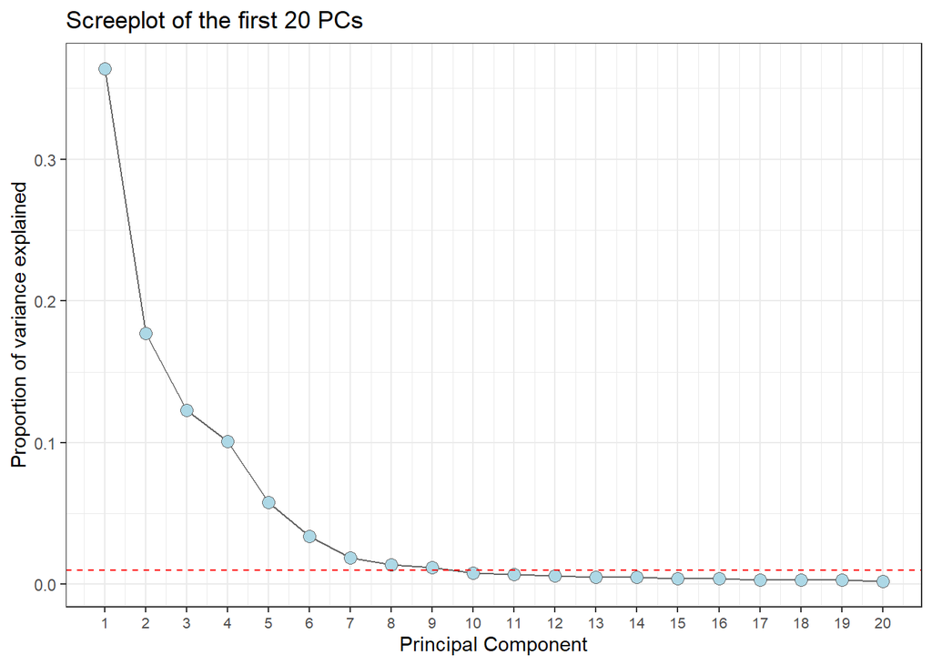

```r
var_explained %>%
  # Subset variance explained to include only the first 20 PCs
  filter(PC <= 20) %>%
  # Plot PC against variance explained
  ggplot(aes(x = PC, y = var_explained)) +
  # Draw a line between points
  geom_line(color = "grey40") +
  # Draw points for each PC
  geom_point(color = "grey40", fill = 'lightblue', shape = 21, size = 3) +
  # Label x axis at integer values between 1 and 20
  scale_x_continuous(breaks = c(seq(1,20))) +
  geom_hline(yintercept = 0.01, linetype = "dashed", color = "red") +
  xlab("Principal Component") +
  ylab("Proportion of variance explained") +
  ggtitle("Screeplot of the first 20 PCs") +
  theme_bw() +
  theme(axis.text.x = element_text(size = 8))
```

You can see that each of the top nine PCs capture more than 1% of the variation in CPM data. Therefore, we investigate these further.

## 2.4 Relation to known variables

By investigating how PCs correlate with known variables, we can assess how much each factor impacts expression.

**Exercise 7: Add the PCs that explain more than 1% variance in CPM values to the metaData for further investigation:**

```r
# Add first 9 PCs to metadata
metaData <- cbind(metaData, pcs$x[,1:9])
```

Correlations between known factors and PCs can be calculated using the `cor()` function, which was used for the replicate correlation in the sample QC.

**Exercise 8: Generate a matrix of correlations between PCs explaining over 1% of CPM variance and known factors**

**Hint**

First, we save the names of variables of interest and subset the metaData using them:

```r
# Calculate the SD of each column in metadata
plot_vars <- apply(metaData, 2, function(x) sd(as.numeric(factor(x)), na.rm=T))

# Save column names that vary (SD is not NA or 0)
plot_vars <- names(plot_vars[!plot_vars %in% c(NA, 0)])

# Remove PC column names
plot_vars <- plot_vars[!grepl("PC", plot_vars)]

# Inspect
plot_vars
```

```
##  [1] "sample_ID"       "sample_type"     "compound_ID"     "compound_CAS"
##  [5] "compound_name"   "compound_abbr"   "mean_ID"         "mean_ID_control"
##  [9] "control_type"    "conc_ID"         "conc_amt"        "conc_max"
## [13] "conc_min"        "rep"             "lib_size"        "read_depth"
## [17] "plate_ID"        "plate_well"      "plate_row"       "plate_col"
## [21] "batch"           "compound_class"  "LOAEL_amt"       "PBPK_equivalent"
## [25] "max_r2"
```

```r
# Subset metadata to include only these columns
heatmap_df <- metaData %>%
  select(any_of(plot_vars))
```

Then we convert these variables to a numeric value and calculate correlations between them and the PCs:

```r
# Convert all variables to numeric values
heatmap_df <- apply(heatmap_df, 2, function(x) as.numeric(factor(x)))

# Calculate correlations between the first 9 PCs and these numeric variables scaled
cxy <- round(cor(pcs$x[,1:9], scale(heatmap_df),
                 use = "pairwise.complete.obs"), 2)

# Inspect
as.data.frame(cxy)
```

|  | sample_ID | sample_type | compound_ID | compound_CAS | compound_name | compound_abbr | mean_ID | mean_ID_control | control_type | conc_ID | conc_amt | conc_max | conc_min | rep | lib_size | read_depth | plate_ID | plate_well | plate_row | plate_col | batch | compound_class | LOAEL_amt | PBPK_equivalent | max_r2 |
| --- | --- | --- | --- | --- | --- | --- | --- | --- | --- | --- | --- | --- | --- | --- | --- | --- | --- | --- | --- | --- | --- | --- | --- | --- | --- |
| PC1 | 0.05 | 0.08 | -0.11 | 0.56 | -0.67 | -0.67 | 0.11 | -0.37 | -0.37 | 0.01 | -0.23 | 0.56 | -0.56 | -0.06 | 0.15 | 0.15 | 0.66 | -0.04 | -0.11 | 0.59 | 0.56 | 0.56 | 0.56 | 0.56 | -0.02 |
| PC2 | -0.19 | -0.05 | 0.01 | -0.31 | 0.35 | 0.35 | -0.24 | 0.64 | 0.64 | -0.28 | 0.21 | -0.31 | 0.31 | 0.10 | 0.06 | 0.06 | -0.34 | -0.02 | 0.02 | -0.26 | -0.31 | -0.31 | -0.31 | -0.31 | 0.26 |
| PC3 | -0.45 | 0.49 | -0.38 | 0.00 | -0.07 | -0.07 | -0.45 | 0.00 | 0.00 | 0.16 | 0.21 | 0.00 | 0.00 | 0.07 | -0.30 | -0.30 | -0.15 | -0.44 | -0.44 | 0.05 | 0.00 | 0.00 | 0.00 | 0.00 | -0.27 |
| PC4 | -0.11 | 0.21 | -0.17 | -0.14 | 0.15 | 0.15 | -0.12 | -0.01 | -0.01 | 0.36 | -0.08 | -0.14 | 0.14 | 0.11 | -0.14 | -0.14 | -0.25 | 0.13 | 0.11 | 0.09 | -0.14 | -0.14 | -0.14 | -0.14 | -0.44 |
| PC5 | -0.15 | -0.22 | 0.01 | -0.61 | 0.48 | 0.48 | -0.19 | 0.53 | 0.53 | -0.25 | 0.16 | -0.61 | 0.61 | -0.07 | 0.05 | 0.05 | -0.40 | 0.06 | 0.07 | -0.25 | -0.61 | -0.61 | -0.61 | -0.61 | -0.09 |
| PC6 | -0.16 | 0.21 | -0.16 | -0.14 | 0.15 | 0.15 | -0.15 | 0.15 | 0.15 | 0.31 | -0.05 | -0.14 | 0.14 | -0.37 | -0.12 | -0.12 | -0.25 | 0.02 | 0.02 | 0.06 | -0.14 | -0.14 | -0.14 | -0.14 | -0.11 |
| PC7 | 0.36 | -0.29 | 0.42 | 0.33 | -0.07 | -0.07 | 0.36 | -0.27 | -0.27 | -0.28 | -0.18 | 0.33 | -0.33 | -0.22 | 0.39 | 0.39 | 0.20 | 0.07 | 0.06 | -0.03 | 0.33 | 0.33 | 0.33 | 0.33 | 0.33 |
| PC8 | 0.32 | -0.22 | 0.35 | 0.24 | 0.00 | 0.00 | 0.28 | -0.24 | -0.24 | -0.22 | -0.28 | 0.24 | -0.24 | 0.44 | 0.03 | 0.03 | 0.10 | -0.04 | -0.02 | -0.21 | 0.24 | 0.24 | 0.24 | 0.24 | 0.13 |
| PC9 | -0.09 | 0.14 | -0.06 | -0.03 | 0.05 | 0.05 | -0.10 | 0.05 | 0.05 | 0.11 | -0.14 | -0.03 | 0.03 | -0.02 | -0.26 | -0.26 | -0.11 | -0.20 | -0.19 | 0.06 | -0.03 | -0.03 | -0.03 | -0.03 | -0.03 |

Such a correlation matrix can be visualized using a heatmap.

**Exercise 9: Create a heatmap of correlations between known factors and the selected PCs:**

**Hint**

`colorRamp2` can be used to generate a custom colour palette.

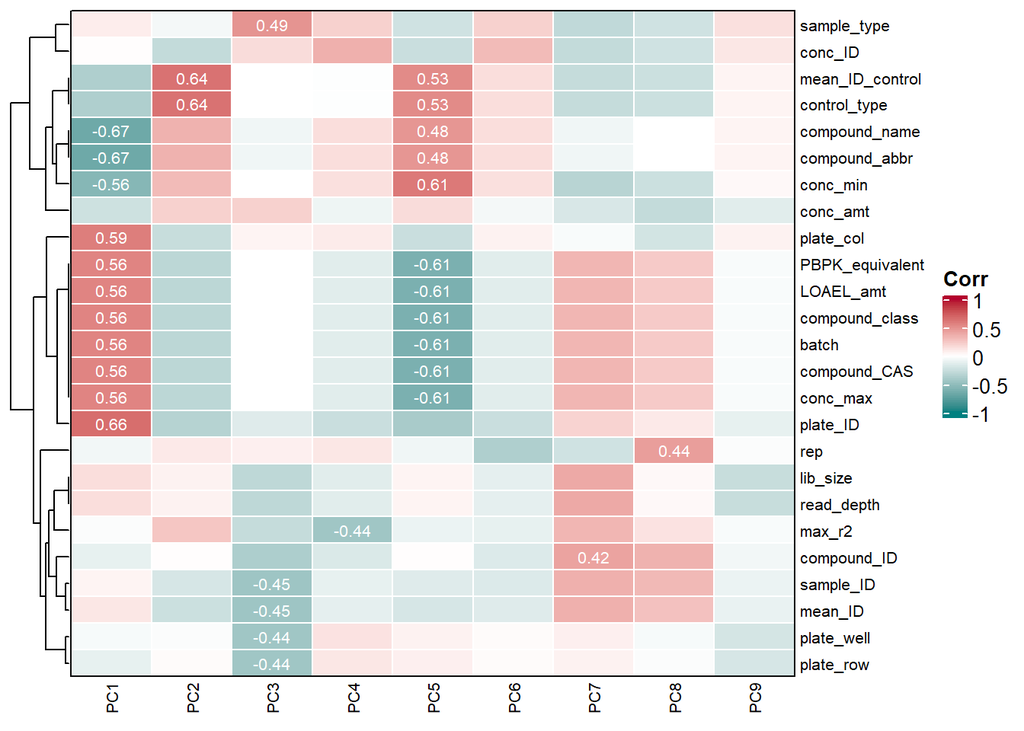

```r
# Create a colour scale from -1 to 1 for the heatmap
col_fun <- colorRamp2(c(-1, 0, 1), c("#008080", "white", "#b3002d"))

# Create a heatmap
Heatmap(
  t(cxy),
  # Use the colour palette
  col = col_fun,
  border = 'grey5',
  # Cluster the variables but not the PCs
  cluster_columns = FALSE,
  show_row_dend = TRUE,
  show_column_dend = FALSE,
  # Set name of legend
  name = "Corr",
  # Format text
  row_names_gp = gpar(fontsize = 8),
  column_names_gp = gpar(fontsize = 8),
  cell_fun = function(j, i, x, y, width, height, fill) {
    grid.rect(x, y, width, height,
              gp = gpar(col = "white", lwd = 1, fill = NA))
    # Print correlation if it is above 0.4
    grid.text(ifelse(abs(t(cxy)[i,j]) > 0.4,
                     sprintf("%.2f", round(t(cxy)[i, j], 2)),
                     ""),
              x, y, gp = gpar(fontsize = 8, col = "white"))
  }
)
```

PCA correlation analysis revealed that PC1 is heavily influenced by technical batch effects (e.g., plate_ID, batch) but also shows moderate associations with biological features like compound class and concentration. PC2 separates control and treated samples, while PC5 reflects dose-related variation. Several other PCs (e.g., PC3, PC4, PC8) correlate with technical variables such as plate position, replicate number, and sample quality, highlighting the need to account for technical effects when interpreting biological variation.

- PC2 separates treated and control conditions
- PC5 captures dose-dependent biological effects

Therefore, we investigate these variables further.

## 2.5 PCA plot

**Exercise 10: Make a plot of two important PCs against each other, coloured by a relevant factor:**

**Hint**

You can use different shapes to visualize multiple factors in the same plot.

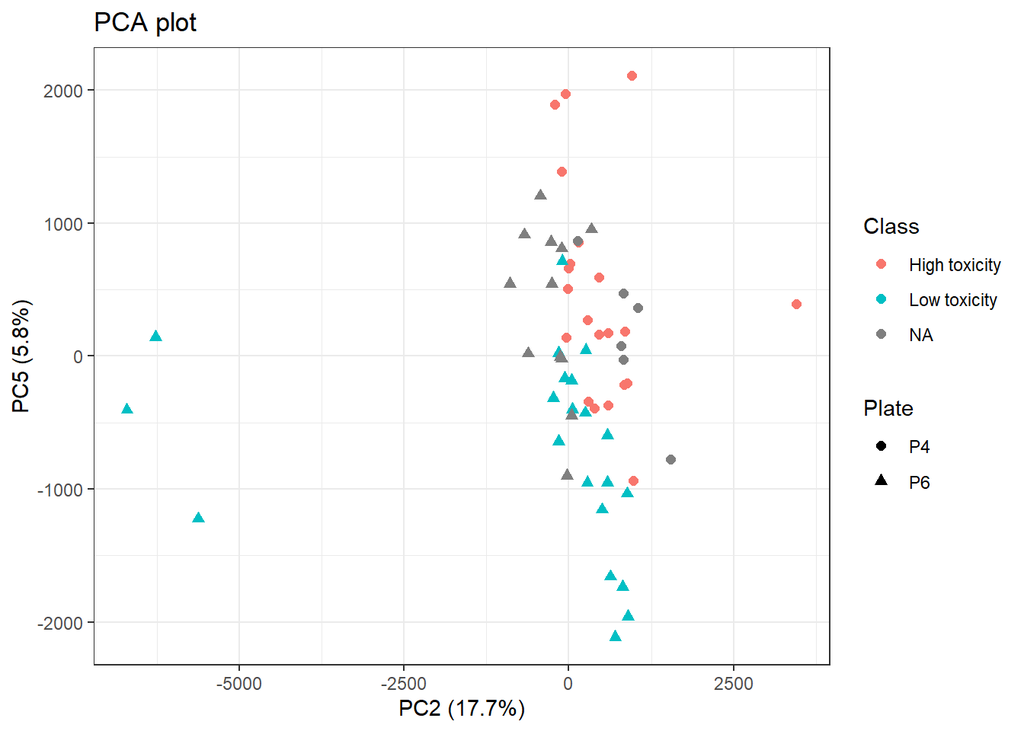

```r
metaData %>%
  # Plot PC2 against PC5
  ggplot(aes(x = PC2, y = PC5,
             # Coloured by compound class and with different shapes for each plate
             color = compound_class, shape=plate_ID)) +
  geom_point(size = 2) +
  # Set labels
  labs(x = paste0("PC2 (", round(100*var_explained[2,2], 2), "%)"),
       y = paste0("PC5 (", round(100*var_explained[5,2], 2), "%)"),
       color = "Class", shape = "Plate") +
  ggtitle("PCA plot") +
  theme_bw()
```

PC2 does capture treatment-related variation, but the biological separation between high and low toxicity compounds is not stark. The overlapping suggests that the main biological effect (e.g. toxicity class) is moderate, not dominant on PC2.

PC5 appears to reflect a biological gradient, possibly dose-response or compound potency: * Low toxicity compounds may have a wider spread in response, especially at higher doses. * High toxicity compounds may induce more consistent responses, hence clustering more tightly.

# 3 Advanced questions

Sometimes a PCA plot can highlight important clusters in your data. Gene loadings can be used to assess which gene’s expression is driving these clusters.

**Exercise 11: Investigate a pattern in your data and identify what genes are responsible for it:**

```r
#
```

```r
#
```

```r
#
```

```r
#
```

```r
#
```

We save these objects (this may not be necessary for your data if you did not change anything):

```r
save(metaData, file=paste0(root_dir, "metaData.Rdata"))
save(countData, file=paste0(root_dir, "countData.Rdata"))
save(cpmData, file=paste0(root_dir, "cpmData.Rdata"))
```

# 4 Session Info

**Exercise 12: Print your session info at the end of the script, knit the R markdown document, and push it to GitHub:**

```r
#
```

That is the end of the entire QC pipeline. Example answers will be available from the `BOO_template` GitHub on Tuesday.